# HCC Usage

The [Holland Computing Center (HCC)](https://hcc.unl.edu/hcc) provides the primary high performance computing resources for J. Yang lab. This document below serves as a reference for the most commonly used commands and workflows for the workload manager [`SLURM`](https://slurm.schedmd.com/). This documentation borrowed much of its text from [Ross-Ibarra Lab wiki](https://github.com/RILAB/lab-docs/wiki) and blended with [HCC documentation](https://hcc-docs.unl.edu/display/HCCDOC/HCC+Documentation).

## Quick Introdution to Computer Clusters

HCC cluster, i.e. `crane`, has a **head node**, which controls the cluster and **compute nodes** which is where the action happens. Crane runs on a cluster workload management system called [Slurm](https://slurm.schedmd.com). For the most part, you interact with Crane using scripts to launch jobs on the compute nodes; you **DONOT** run processes on the head node. The only tasks that acceptable on the head node are:

- Downloading and transfering files (with `wget` or `scp`)
- Compiling/building files
- Installing R packages
- Submitting or checking on jobs

## File systems on crane

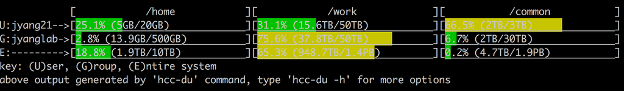

Key: User, Group and Entire system.

### $HOME:

- $HOME directories are backed up daily.
- You can read and write.
- But the size is small (**20GB** per user).
- Normally used for configure files, user defined functions, user installed software packages.

### $WORK:

- `$WORK` is large, **50TB** per user.
- **NOT backed up**
- But purge policy exists on `/work`, see [here](https://hcc-docs.unl.edu/x/4BEF).
- For computing and working. But, **DONOT use it to store RAW Data**.

### $COMMON:

Note: To gain access to the path on worker nodes, a job must be submitted with the following SLURM directive:

```
#SBATCH --licenses=common
srun --licenses=common
```

## Connecting to crane:

- Get an account [here](http://hcc.unl.edu/): ask Jinliang to learn our group id.
- Set up DUO.
- Connecting to crane using SSH.

#### SSH Config

Make your life a little easier by adding the following to `~/.ssh/config`:

```
Host crane
    HostName crane.unl.edu
    User jyang21
```

## Getting to Know Slurm

Slurm is job managing system: you submit jobs via batch scripts. These batch scripts have common headers; we will see one below.

First, we can get a sense of our lovely cluster with `sinfo`:

```
$ sinfo
PARTITION AVAIL  TIMELIMIT  NODES  STATE NODELIST
hi           up   infinite      4 drain* c8-[25,39-40],c9-35
hi           up   infinite     64    mix c8-[22-24,30-38,45,54-58,60-61,84-87]
hi           up   infinite      6   idle c8-[42-44,59],c9-[94,97]
serial       up   infinite      2  down* c10-[12,40]
serial       up   infinite     15    mix c10-[8-9,11,13-22,41-42]
serial       up   infinite     18   idle c10-[10,23-39]
bigmeml      up   infinite      1  mixed bigmem2
bigmeml      up   infinite      5    mix bigmem[1,3-6]
bigmemm      up   infinite      1  mixed bigmem2
bigmemm      up   infinite      5    mix bigmem[1,3-6]
bigmemh      up   infinite      1  mixed bigmem2
bigmemh      up   infinite      5    mix bigmem[1,3-6]
```

Here we see our `PARTITION` and `TIME LIMIT`, and all of their inferior but still useful friends.

Note that there is a column of `STATE`, which indicates the state of the machine. A better way of looking at what’s going on on each machine is with `squeue`, which is the job queue.

```
$ squeue
         JOBID PARTITION     NAME     USER ST       TIME  NODES NODELIST(REASON)
       1541913   bigmemh some_job someone  R 6-04:27:02      1 bigmem6
       1613530   bigmemm some_job someone PD       0:00      1 (Resources)
       1544863   bigmeml     some_job someone R 5-10:59:32      1 bigmem2
       1472908        hi  some_job someone  R 5-22:16:23      1 c8-22
       1477386    serial some_job  someone  R 14-03:19:29      1 c10-11
```

This shows each job ID (very important), partition the job is running on, name of person running the job. Also note `TIME` which is how long a job has been running.

```
$ scancel JOBID
```

It’s that easy! Slurm is pretty boring so far; all we can do is look at the cluster and try to kill jobs. Let’s see how to submit jobs.

## An Example Slurm Batch Script Header

We wrap our jobs in little batch scripts, which is nice because these also help make steps reproducible. We’ll see how to write batch scripts for Slurm in the next section, but suppose we had one written called `steve.sh`. To keep your directory organized, I usually keep a `scripts/` directory (or even `slurm-scripts/` if you have lots of other little scripts).

I like to organize each of my projects in their own directory in a general `~/projects/` directory. In each project directory, I make a directory called `slurm-log` for Slurm’s logs. Tip: use these logs, as these are **very** helpful in debugging. I separate them from my project because they fill up directories rather quickly.

Let’s look at an example batch script header for a job called `steve` (which is run with script `steve.sh`) that’s in a project directory named `your-cool-project` (you’re going to change these parts).

```
#!/bin/bash -l
#SBATCH -D /home/vince251/projects/your-cool-project/
#SBATCH -o /home/vince251/projects/your-cool-project/slurm-log/steve-stdout-%j.txt
#SBATCH -e /home/vince251/projects/your-cool-project/slurm-log/steve-stderr-%j.txt
#SBATCH -J steve
#SBATCH -t 24:00:00
set -e
set -u

# insert your script here
```

- `-D` sets your project directory.
- `-o` sets where standard output (of your batch script) goes.
- `-e` sets where standard error (of your batch script) goes.
- `-J` sets the job name.
- `-t` sets the time limit for the job, 24:00:00 indicates 24 hours.

Note that the programs in your batch script can redirect their output however they like — something you will like want to do. This is the standard output and standard error of the batch script itself.

Also note that these directories must already be made — Slurm will not create them if they don’t exist. If they don’t exist, `sbatch` will not work and die silently (since there’s no place to write standard error). If you keep trying something and it doesn’t log the error, make sure all these directories exist.

The time limit for the job should be greater than the estimated time to complete your job. Time-and-a-half or twice as much time as you think it will take are good rules. If your job reaches this time limit it will be killed. It’s frustrating to lose a job because you underestimate the time. Alternatively, you can set this with the –time flag (instead of -t, e.g. –time=1-00:00 sets a time limit of one day)

## An example script

Try running this test script:

```
#!/bin/bash -l
#SBATCH -D /home/USERNAME
#SBATCH -J bob
#SBATCH -o /home/USERNAME/out-%j.txt
#SBATCH -e /home/USERNAME/error-%j.txt
#SBATCH -t 24:00:00
#SBATCH --array=0-8

bob=( 1 1 1 2 2 2 3 3 3 )
sue=( 1 2 3 1 2 3 1 2 3 )

block=${bob[$SLURM_ARRAY_TASK_ID]}
min=${sue[$SLURM_ARRAY_TASK_ID]}

echo "$block is $min"
```

Array jobs can also process a fixed number of files. This set of files can be streamed into `sed` which grabs the appropriate line (given by the array job), and then passes that to the pipeline. It’s wise to use `sort` (with `-s` for stable) to ensure your input order does not change. For example:

```
find data/aln -name "*.bam" | xargs -n1 -I{} basename {} .bam | \
   sort -s | sed -n "$SLURM_ARRAY_TASK_ID"p | \
   xargs -n1 -I{} samtools sort -@ 10 -m2G data/aln/{}.bam $ODIR/{}.sorted
```

Do **not** use this if you have spaces in your file name. We could use `-print0`, but that would interfere with other commands.

## Know About The Queue

**We share the cluster**. There is a queue established with multiple users submitting jobs. This means often times SLURM will allocate resources to your jobs only when nodes in your desired partition are open and not occupied by jobs from other users. In order to submit a job (covered in the next section), you must specify which partition your job(s) will run on. Based on your memory and cpu requirements, you can choose to run with the following partition options:

`bigmeml` (low): This means that your job might be killed at any time (but then restarted). Great for soaking up unused cycles with short jobs; a particularly good fit for large array jobs with short run times.

`bigmemm` (medium): This means your jobs might be suspended, but will resume when a high priority job finishes. Good for long jobs that need lots of cpu, but *NOT* recommended for MPI jobs. Up to 100% of idle resources can be used.

`bigmemh` (high) or (hell yeah, I want this to run): Your job will kill/suspend lower priority jobs. High priority means your jobs will keep the allocated hardware until it’s done or there’s a system or power failure. Limited to the number of CPUs your group contributed. Please check with Jeff or ask others before running anything using more than 8cpu on `bigmemh`, as we only have 64 slots on this queue.

`med`: These are the older parallel nodes. For many jobs not needing high memory, the parallel queue is still the way to go. There are many hundreds of cpu there, but we only have access to them at medium priority. Note that each node in this queue only has 24 cpu and 32G of RAM, so plan your scripts accordingly.

To use these, we specify the partition in either `sbatch` or our batch script itself.

To do so with `sbatch`, do:

```
$ sbatch -p bigmemh steve.sh
```

Or, we can do so in the batch script itself by adding a line:

```
#SBATCH --partition=bigmemh
```

You can also submit jobs to a specific node in bigmem (say bigmem9) by including `-p bigmemh --nodelist=bigmem9` in your sbatch command line.

## Submitting Jobs

We submit our batch scripts with `sbatch`. For example, we can submit the `steve.sh` job (assuming it’s in a `scripts/` directory):

```
$ sbatch -p bigmemm scripts/steve.sh
```

It’s that easy! After submitting jobs, check with `squeue` that it’s still running (and didn’t immediately fail, do to syntax error or a program not being in your `$PATH` or a [module not loaded](https://github.com/RILAB/farm-guide/blob/master/Beginners_guide_to_farm.md#modules)). If you don’t see a `steve` job in `squeue`, then it’s time to debug. Use these `slurm-log/` directory to standard output and standard error to figure out what happened. I use `ls -lrt` (`ls` with reverse time sort) to see the most recent Slurm log, i.e.:

```
$ ls -lrt slurm-log/
-rw-rw-r-- 1 vince251 vince251            0 Sep 25 11:07 dwgeval-stderr-5370.txt
drwxrwxr-x 2 vince251 vince251        12288 Sep 25 11:07 .
-rw-rw-r-- 1 vince251 vince251           47 Sep 25 11:34 dwgeval-stderr-5368.txt
```

Hey cool, that’s the name of the last Slurm job (but double check against the job ID that `sbatch` gives you when you run it. Then look at this in less or something.

## Allocating Resources

If you’re using a process that requires more than one CPU/thread/process, you’ll need to allocate more tasks. It’s very important you do this, or else the cluster manager won’t know how much CPU your program is running, and allocate resources thinking it has more available than it does. This really gums up the works, so don’t do this. To specify the number of tasks (roughly, number of processes), use `sbatch --ntasks=x` where `x` is the number.

Farm assigns each CPU/task 8GB of memory by default for all bigmem queues, and 2.6GB of memory per CPU/task for the parallel queue. In order to suspend jobs on the bigmemm and bigmeml queues, farm has changed how memory can be requested. Now, even if you need only 1 CPU and 128Gb of memory, 16 CPU will be counted against the lab’s allotment. Warn others if you will be monopolizing lab resources accordingly!

## Array jobs

Slurm supports job arrays, which make it easy to submit many jobs of a similar type at once. The basic syntax is:

```
$ sbatch --array=<start>-<end>
```

You can also specify this in the script you are submitting via sbatch:

```
#!/bin/bash -l
#SBATCH --array=0-50
```

This will submit all 51 jobs simultaneously, and they will run as resources become available. You might not want this if you’re submitting on `bigmemh`, for example. Luckily, you can limit how many jobs of an array are running simultaneously. Do this with:

```
--array=0-50%10
```

This allows 10 jobs to run at the same time.

Slurm also comes with some built in variables for managing file names. **SLURM_ARRAY_JOB_ID** will be set to the first job ID in the array, and **SLURM_ARRAY_TASK_ID** will be set to the index of the current job array. You can use these in filenames by inserting **%A** or **%a** into your bash script, which will be replaced with **SLURM_ARRAY_JOB_ID** and **SLURM_ARRAY_TASK_ID** respectively. For example, `slurm-%A_%a.out` will be replaced with `slurm-7358_1.out`. You can also use these to index arrays in your script, or to keep track of output file names. For example, if I used an array for all 10 maize chromosomes, `--array=1-10`, I could write to file within my script with:

```
outfile.chr${SLURM_ARRAY_TASK_ID}.txt
```

More information is available [here](http://www.schedmd.com/slurmdocs/job_array.html) and an example script is [above](https://github.com/RILAB/lab-docs/wiki/Using-Farm#an-example-script).

## Monitoring Stuff

You can monitor jobs a few ways:

- [Agri Ganglia](http://stats.cse.ucdavis.edu/ganglia/?r=hour&s=descending&c=Agri)
- `squeue`: see if they are still running.
- Watching your files grow.
- Advanced: `ssh` to a node and use `top`, but **do not run anything on the nodes this way**. Every time you do this, Bill, Jeff, or I will have to ruthlessly strangle a young kitten. So if you not sure what this section means, save the kittens and don’t `ssh` to the nodes.

## Managing Your Home Directory

An extension of **Monitoring Stuff**, you should also monitor the amount of space you data and files are taking up.

Use `du -sh` to check the amount of storage being used in any given directory. Just `cd` to the directory of your choice and enter that command and options. **Check directory size regularly**.

Use `df -h` to check the size of your drive, it’s total storage being used, how much you have left on your drive, and where that drive is mounted.

```
$ df -h
Filesystem                    Size  Used Avail Use% Mounted on
/dev/sda1                     854G  638G  173G  79% /
none                          4.0K     0  4.0K   0% /sys/fs/cgroup
udev                           32G  4.0K   32G   1% /dev
tmpfs                         6.3G  1.4M  6.3G   1% /run
none                          5.0M     0  5.0M   0% /run/lock
none                           32G     0   32G   0% /run/shm
none                          100M     0  100M   0% /run/user
nas-8-0:/export/1/sbhadral     11T  7.9T  2.3T  78% /home/sbhadral
```

Looks like it’s time for me to start cleaning up my directories…

## Shared scratch space

Each node has a `/scratch/` directory, which you can use to write intermediate files. But as this is space shared across all Farm users, you need to remove files when you are finished. Usually, you can do this with `rm` within your submission script, but sometimes files can be left behind, like if your script encounters errors before erasing the file.

If this happens in an array job, you might not know which nodes to clean up. First, find all nodes that might be affected with `sinfo`, then loop through the nodelist to ssh and remove files `` for i in `scontrol show hostname c8-[62-64,67-77,87-89,91-96] `; do echo $i; ssh $i rm -rf /scratch/mstitzer/*;done ``

## Transferring Big Data onto Farm (`screen` and `rsync` )

When transferring files to/from a server, `scp` is a nice command for small data, as those are very quick and do not require babysitting (enter `man scp` in the command-line for more details). With larger files, the transfers can become problematic as they take quite some time. No one wants to sit and watch files transfer. Solution: `screen` and `rsync`.

`screen` allows you to enter an overlay of your terminal. The screen terminal environment is nearly identical to your previous terminal command-line, but you can now simply “detach” the screen and have it run in the background. No risk of connection drops, you can shutdown your computer and still have your tasks running. To get back to your screen, just “reattach” and continue. (refer to `man screen` for more details).

Examples:

Enter `screen`:

```
$ screen
```

To detach: press “ctrl + a” then “d”. This will return you to your regular command-line.

To reattach:

```
$ screen -r
```

This will recover your screen immediately if you only have 1 running. If you have multiple screens running, this will return a list of those screens and their respective IDs in this format [pid.tty.host].

With multiple sessions to choose from, reattach with the following.

```
$ screen -D -r [4137.pts-65.farm]
```

(NOTE: check up on your active screen sessions with `screen -list` )

To terminate screen, enter the respective screen and enter `exit`.

(NOTE: From personal experience. When you enter a screen, it is possible to enter a screen within that screen, and a screen within that screen…etc. You can get lost in screen limbo. If you have watched the film Inception(2010) you will understand. Just terminate each subscreen with `exit`. You will know when you’re out, when you see [screen is terminating] at the top of your window.)

Now that you know how `screen` works, you can use it in conjunction with `rsync`.

`rsync` copies/transfers files fast and reliably with lots of options and versatility (refer to `man rsync`). After entering `screen`, rsync the files of your choosing from their location into the target destination on farm.

Example:

```
$ screen

$ rsync -avz <my files> farm:/home/sbhadral/Projects/Rice_project/fixed_fastqs/
```

Detach screen and check up on your transfer whenever.

(NOTE: You **cannot** transfer from server to server remotely, you need to be logged into one of the servers. e.g. rilab@169.237.206.32:/home/blah/.. to farm:/home/sbhadral/.. )

## Using R with Slurm

Often, we need to work with R interactively on a server. To do this, we use `srun` with the following options:

```
$ srun -p your-partition -t 2:00:00 --pty R
```

This will drop you into an interactive R session on the partition specified by `-p`. `--pty` launches srun in terminal in pseudoterminal mode, which makes R behave as it would on your local machine. With srun you still have to set a time limit.

If you want to render R plots to your local computer through X11, here is a solution:

```
$ srunx your-partition
```

Make sure your `X11` is open before you typing the command.

Using `ssh -Y` with `X11` may seem like good idea, but this does not specify a partition to work interactively in, so you will end up running things on the head node. Bad idea.

## Warnings

**Do not run anything on the headnode** except cluster management tools (`squeue`, `sbatch`, etc), compilation tasks (but usually ask CSE help for big apps), or downloading files. If you run anything on the headnode, you will disgrace your lab. How embarrassing is this? Imagine if you had to give your QE dressed up like [Richard Simmons](http://i.imgur.com/7VqJ9oY.jpg). It’s that embarrassing.

**Back up your stuff**, as Farm does not back up your stuff. Using git is a good option.

**Monitor your disk space**, as it can fill up quickly.